# HW4

An Exploration of (or, a story about) Traffic Stops

Colin Flaherty

25 April 2018

```
##
##  Pearson's Chi-squared test
##
## data:  traffic.table1
## X-squared = 745.32, df = 4, p-value < 2.2e-16
```

We begin in perhaps the most logical, although pessimistic, way. A chi-squared test reveals that it is highly unlikely that race and the search of a vehicle in a traffic stop are statistically independent.

|  | Estimate | Std. Error | z value | Pr(>\|z\|) |
| --- | --- | --- | --- | --- |
| (Intercept) | -4.4431089 | 0.2439600 | -18.2124461 | 0.0000000 |
| `Driver Race`Black | 1.6468602 | 0.2448363 | 6.7263732 | 0.0000000 |
| `Driver Race`Native American | 1.0026279 | 0.7594039 | 1.3202828 | 0.1867406 |
| `Driver Race`Other/Unknown | -0.0881095 | 0.3027655 | -0.2910156 | 0.7710394 |
| `Driver Race`White | 0.4239981 | 0.2482116 | 1.7082122 | 0.0875970 |
| `Driver Hispanic`Yes | 0.6145309 | 0.0783665 | 7.8417555 | 0.0000000 |

We use a Generalized Linear Model, with a binomial distribution, to examine further. We find that whether or not a driver is black is a statistically significant predictor of whether or not a vehicle is searched, with a positive coefficient. This means being black positively correlates with vehicle searches. whether or not a driver is hispanic is also a statistically significant predictor of whether or not a vehicle is searched, with a positive coefficient. This means being hispanic positively correlates with vehicle searches.

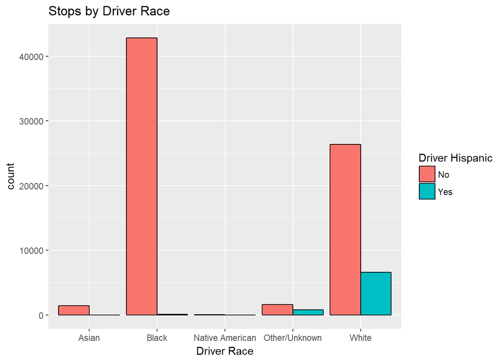

The above bar chart reveals the number of drivers of each race present in the data set- that is, the number of drivers of each race pulled over in this “large southeastern city” in 2016. If we knew the demographic statistics of the city, we could make examinations of the relationship between the proportion of a given race in the city’s population, and their proportion of the traffic stops that year. But, we can’t

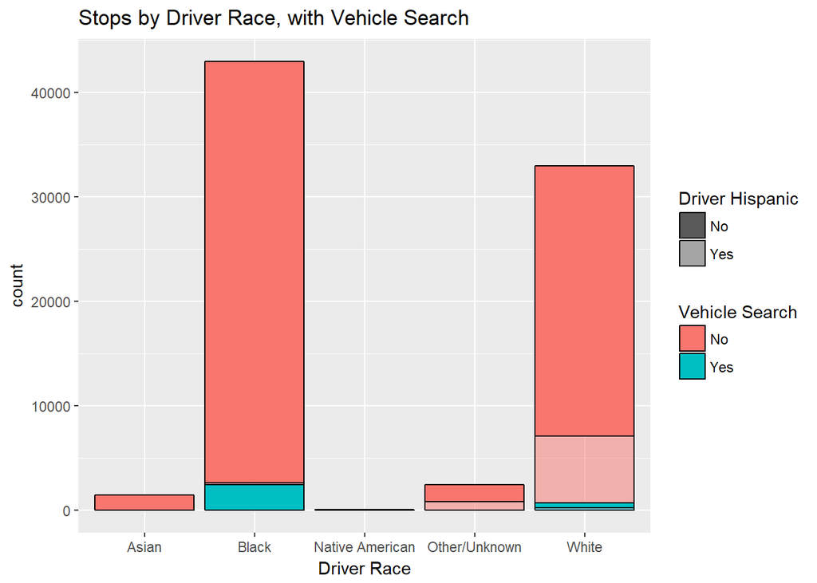

Manipulating the plot in this way reveals the proportion of vehicle searches out of all traffic stops by race. We see that although approximately 1/3 more blacks were stopped than whites, their cars were searched at a rate much higher than that of whites. We examine this first.

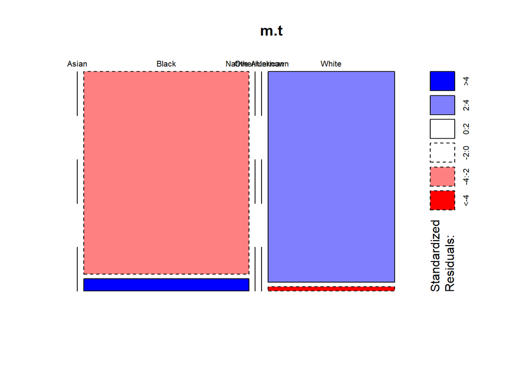

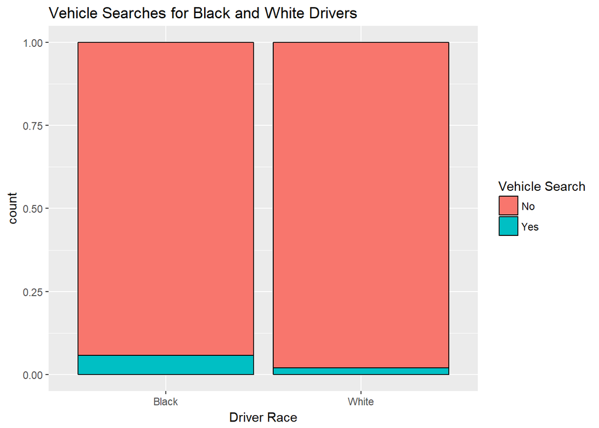

These 2 plots offer a better visualization of the disparity between the proportions of whites and blacks who experience vehicle searches.

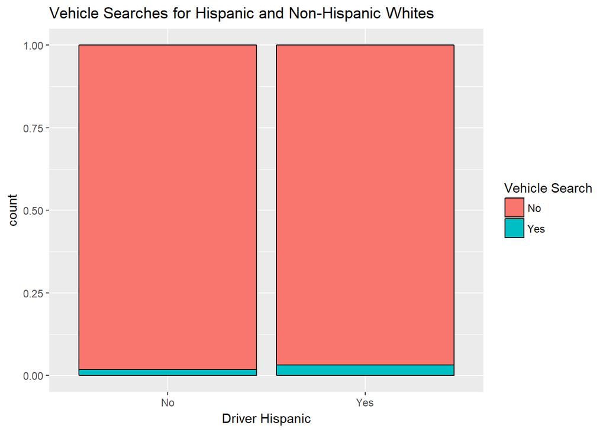

We see here that among whites, the proportion of hispanics who have their car searched is higher than that of non-hispanics.

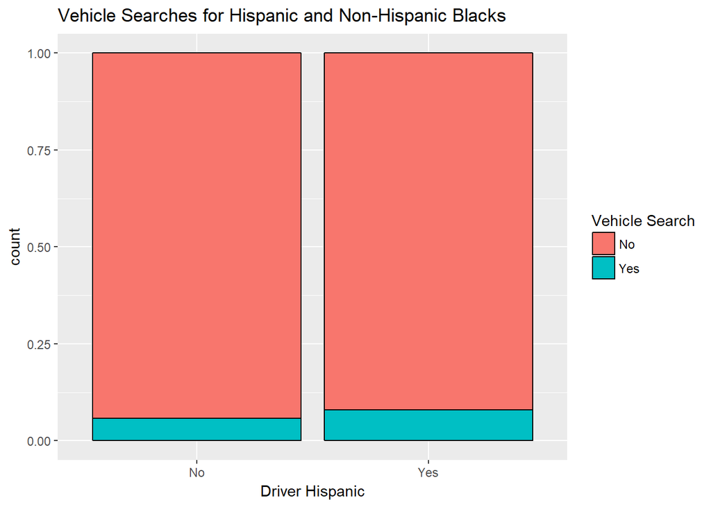

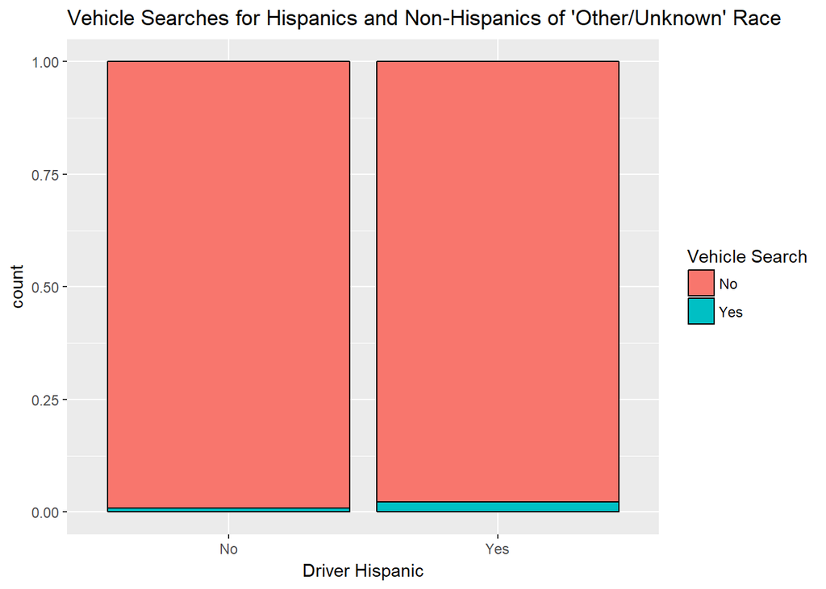

Examining the analogous question for both drivers noted as black and “Other/Unknown,” we see the trend continue. In all cases, drivers who are hispanic proportionally experience more vehicle searches.

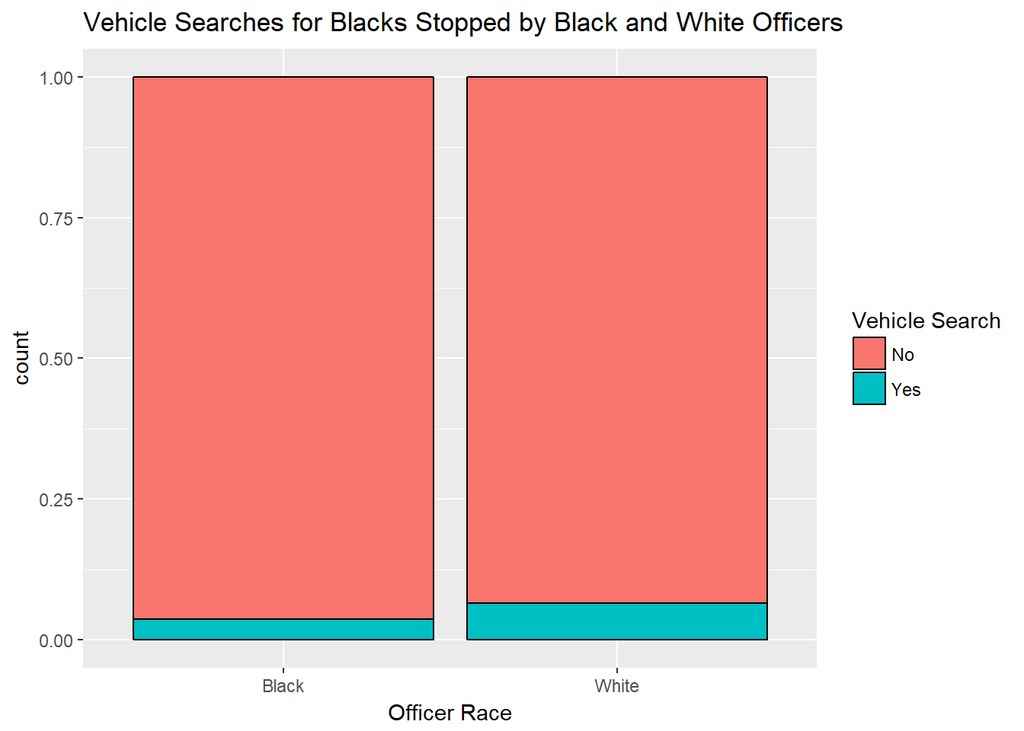

The graph above shows only black drivers. We see here that black officers search the cars of black drivers at a lower rate than do white officers.

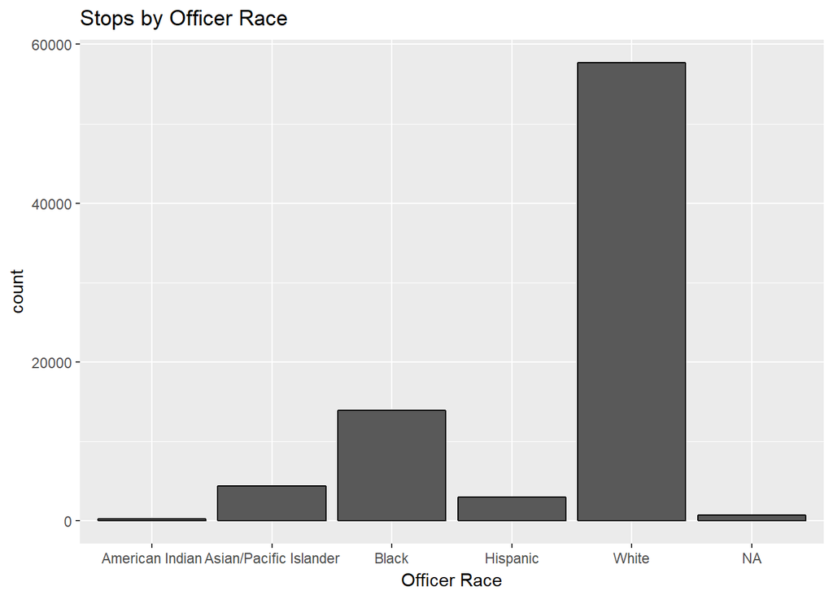

Here we see how many times officers of each race appear in the data set- that is, how many stops they made. If we knew how many officers of each race were on the force, we could examine the relationship between the proportion of officers of a certain race, and the proportion of stops made by officers of this race. But, we can’t.

|  | Estimate | Std. Error | z value | Pr(>\|z\|) |
| --- | --- | --- | --- | --- |
| (Intercept) | -14.5659849 | 882.7423700 | -0.0165008 | 0.9868348 |
| `Driver Race`Black | 11.6880356 | 882.7424364 | 0.0132406 | 0.9894358 |
| `Driver Race`Native American | 1.5379301 | 0.7787418 | 1.9748909 | 0.0482805 |
| `Driver Race`Other/Unknown | -0.0000830 | 916.0651233 | -0.0000001 | 0.9999999 |
| `Driver Race`White | 11.9632952 | 882.7425221 | 0.0135524 | 0.9891871 |
| `Officer Race`Asian/Pacific Islander | 9.9912739 | 882.7429422 | 0.0113184 | 0.9909694 |
| `Officer Race`Black | 9.8655045 | 882.7426557 | 0.0111760 | 0.9910831 |
| `Officer Race`Hispanic | 10.6147411 | 882.7429473 | 0.0120247 | 0.9904059 |
| `Officer Race`White | 10.1658539 | 882.7424141 | 0.0115162 | 0.9908116 |
| `Driver Race`Black:`Officer Race`Asian/Pacific Islander | -10.7167067 | 882.7430195 | -0.0121402 | 0.9903137 |
| `Driver Race`Native American:`Officer Race`Asian/Pacific Islander | -11.5292869 | 624.1951218 | -0.0184706 | 0.9852634 |
| `Driver Race`Other/Unknown:`Officer Race`Asian/Pacific Islander | 0.2981279 | 916.0659515 | 0.0003254 | 0.9997403 |
| `Driver Race`White:`Officer Race`Asian/Pacific Islander | -11.1487942 | 882.7431066 | -0.0126297 | 0.9899232 |
| `Driver Race`Black:`Officer Race`Black | -10.2556236 | 882.7427243 | -0.0116179 | 0.9907305 |
| `Driver Race`Native American:`Officer Race`Black | -11.4035175 | 202.5179622 | -0.0563087 | 0.9550959 |
| `Driver Race`Other/Unknown:`Officer Race`Black | -0.4942436 | 916.0655817 | -0.0005395 | 0.9995695 |
| `Driver Race`White:`Officer Race`Black | -11.6320737 | 882.7428164 | -0.0131772 | 0.9894864 |
| `Driver Race`Black:`Officer Race`Hispanic | -10.5247262 | 882.7430199 | -0.0119228 | 0.9904872 |
| `Driver Race`Native American:`Officer Race`Hispanic | -12.1527542 | 509.6537201 | -0.0238451 | 0.9809761 |
| `Driver Race`Other/Unknown:`Officer Race`Hispanic | -10.6147410 | 923.1270735 | -0.0114987 | 0.9908256 |
| `Driver Race`White:`Officer Race`Hispanic | -11.5262273 | 882.7431165 | -0.0130573 | 0.9895821 |
| `Driver Race`Black:`Officer Race`White | -9.9607434 | 882.7424808 | -0.0112839 | 0.9909970 |
| `Driver Race`Other/Unknown:`Officer Race`White | 0.3678715 | 916.0651857 | 0.0004016 | 0.9996796 |
| `Driver Race`White:`Officer Race`White | -11.3777319 | 882.7425673 | -0.0128891 | 0.9897163 |

This model shows no statistically significant interactions between officer race and driver race, suggesting the race of an officer does not influence the races of the drivers he pulls over.

```
##  [1]  1  2  3  4  5  6  7  8  9 10 11 12 13 14 15 16 17 18 19 20 21 22 23
## [24] 24 25 26 27 28 29 30 31 32 33 34 35
```

|  | Estimate | Std. Error | t value | Pr(>\|t\|) |
| --- | --- | --- | --- | --- |
| (Intercept) | 5029.7798 | 343.44967 | 14.644882 | 0 |
| Experience | -152.6322 | 16.64019 | -9.172504 | 0 |

We see from this model that experience is a statistically significant predictor of the stops an officer makes per year, with a negative coefficient. This suggests the more experience a police officer has, the fewer traffic stops they make.

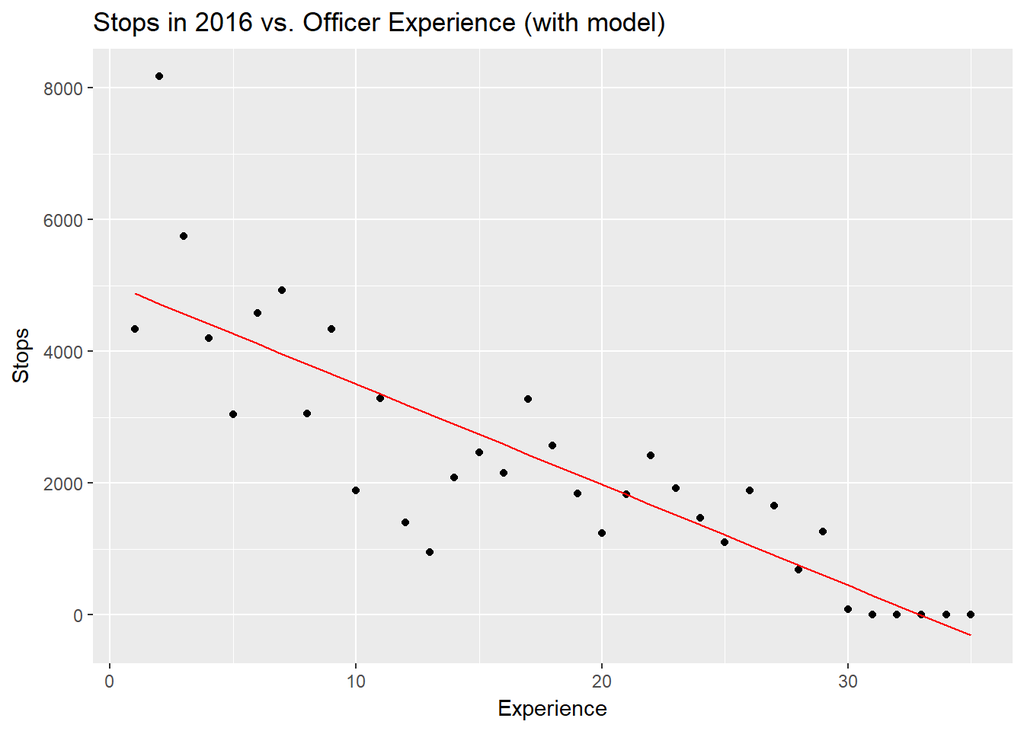

Visually, we see our model fits the data quite well. This effect may be due to officers transferring away from patrols and into more managerial roles.